# lab8

## Part 2

### Question 4

```r
w %>%
  filter(season=="winter") %>%
  arrange(desc(TMAX))
```

```
## # A tibble: 4,242 × 40
##    STATION_NAME DATE        PRCP  SNWD  SNOW  ACMH  ACSH  PSUN  TSUN  TAVG  TMAX
##    <chr>        <date>     <dbl> <dbl> <dbl> <dbl> <dbl> <dbl> <dbl> <dbl> <dbl>
##  1 LANSING CAP… 1999-02-11  0.14     0     0    NA    NA    NA    NA    53    69
##  2 LANSING CAP… 2001-12-05  0.02    NA    NA    NA    NA    NA    NA    62    69
##  3 LANSING CAP… 1982-12-02  0.1      0     0   100   100     0     0    NA    66
##  4 LANSING CAP… 1982-12-03  0.93     0     0   100   100     0     0    NA    66
##  5 LANSING CAP… 1998-12-03  0        0     0    NA    NA    NA    NA    58    66
##  6 LANSING CAP… 1970-12-01  0.02     0     0    70    90     9    48    NA    65
##  7 LANSING CAP… 1982-12-25  0.77     0     0    80    90    35   186    NA    65
##  8 LANSING CAP… 1998-12-06  0.94     0     0    NA    NA    NA    NA    53    65
##  9 LANSING CAP… 1971-12-15  1.17     0     0   100    90     4    24    NA    64
## 10 LANSING CAP… 1984-02-23  0        0     0     0     0    NA   656    NA    64
## # … with 4,232 more rows, and 29 more variables: TMIN <dbl>, AWND <dbl>,
## #   WSFG <dbl>, WT09 <lgl>, WT14 <lgl>, WT07 <lgl>, WT01 <lgl>, WT15 <lgl>,
## #   WT17 <lgl>, WT06 <lgl>, WT21 <lgl>, WT05 <lgl>, WT02 <lgl>, WT11 <lgl>,
## #   WT22 <lgl>, WT04 <lgl>, WT13 <lgl>, WT16 <lgl>, WT08 <lgl>, WT18 <lgl>,
## #   WT03 <lgl>, WT10 <lgl>, WT19 <lgl>, weekday <chr>, month <chr>, day <dbl>,
## #   year <dbl>, week <dbl>, season <chr>
```

### Question 5

```r
w <- w %>%
  mutate(above_freezing= (TMAX>32))
w
```

```
## # A tibble: 17,167 × 41
##    STATION_NAME DATE        PRCP  SNWD  SNOW  ACMH  ACSH  PSUN  TSUN  TAVG  TMAX
##    <chr>        <date>     <dbl> <dbl> <dbl> <dbl> <dbl> <dbl> <dbl> <dbl> <dbl>
##  1 LANSING CAP… 1970-01-01  0.1      1   2.4   100   100     5    30    NA    29
##  2 LANSING CAP… 1970-01-02  0.08     3   1.3   100   100     0     0    NA    26
##  3 LANSING CAP… 1970-01-03  0.02     4   0.4    90    90    34   186    NA    25
##  4 LANSING CAP… 1970-01-04  0.01     4   0.4    70    60    42   228    NA    21
##  5 LANSING CAP… 1970-01-05  0        4   0      30    60    62   342    NA    22
##  6 LANSING CAP… 1970-01-06  0        4   0.2    80    80    52   288    NA    18
##  7 LANSING CAP… 1970-01-07  0.03     4   0.7    90    60    35   192    NA    13
##  8 LANSING CAP… 1970-01-08  0.02     4   0.5    90    80    56   312    NA    15
##  9 LANSING CAP… 1970-01-09  0.01     4   0.2    60    70    59   330    NA    21
## 10 LANSING CAP… 1970-01-10  0.01     4   0.5    90   100    33   186    NA    23
## # … with 17,157 more rows, and 30 more variables: TMIN <dbl>, AWND <dbl>,
## #   WSFG <dbl>, WT09 <lgl>, WT14 <lgl>, WT07 <lgl>, WT01 <lgl>, WT15 <lgl>,
## #   WT17 <lgl>, WT06 <lgl>, WT21 <lgl>, WT05 <lgl>, WT02 <lgl>, WT11 <lgl>,
## #   WT22 <lgl>, WT04 <lgl>, WT13 <lgl>, WT16 <lgl>, WT08 <lgl>, WT18 <lgl>,
## #   WT03 <lgl>, WT10 <lgl>, WT19 <lgl>, weekday <chr>, month <chr>, day <dbl>,
## #   year <dbl>, week <dbl>, season <chr>, above_freezing <lgl>
```

### Question 6

```r
w %>%
  group_by(year) %>%
  summarize(highest_temp=sum(above_freezing==FALSE)) %>%
  arrange(desc(highest_temp))
```

```
## # A tibble: 47 × 2
##     year highest_temp
##    <dbl>        <int>
##  1  1978           80
##  2  2014           80
##  3  1977           74
##  4  1985           74
##  5  1989           70
##  6  2010           70
##  7  2008           69
##  8  1980           67
##  9  1995           67
## 10  2003           67
## # … with 37 more rows
```

### Question 7

```r
w %>%
  group_by(year) %>%
  summarize(tot_parcipitation = sum(PRCP)) %>%
  arrange(desc(tot_parcipitation))
```

```
## # A tibble: 47 × 2
##     year tot_parcipitation
##    <dbl>             <dbl>
##  1  2013              41.5
##  2  1975              39.6
##  3  2011              38.9
##  4  2009              38.1
##  5  1990              37.7
##  6  2014              37.5
##  7  1972              37.4
##  8  1986              37.1
##  9  2006              37.0
## 10  2008              36.6
## # … with 37 more rows
```

## Part 3

### Question 8

```r
w %>%
  group_by(month,year) %>%
  summarize(tot_sun_min = sum(TSUN)) %>%
  arrange(desc(tot_sun_min))
```

```
## # A tibble: 564 × 3
## # Groups:   month [12]
##    month  year tot_sun_min
##    <chr> <dbl>       <dbl>
##  1 Jun    1988       23479
##  2 May    1977       23046
##  3 Jul    1976       21966
##  4 Jun    1971       21840
##  5 Jul    1983       21588
##  6 Jul    1971       21480
##  7 May    1988       21304
##  8 Jul    1977       21132
##  9 Jul    1982       21108
## 10 Jul    1974       21060
## # … with 554 more rows
```

```r
w %>%
  group_by(month,year) %>%
  summarize(avg_sun_min = mean(TSUN,na.rm=T)) %>%
  arrange(desc(avg_sun_min))
```

```
## # A tibble: 564 × 3
## # Groups:   month [12]
##    month  year avg_sun_min
##    <chr> <dbl>       <dbl>
##  1 Jun    1988        783.
##  2 May    1977        743.
##  3 Jun    1971        728
##  4 Jul    1976        709.
##  5 Jul    1983        696.
##  6 Jul    1971        693.
##  7 May    1988        687.
##  8 Jun    1991        687.
##  9 Jun    1983        686.
## 10 Jul    1977        682.
## # … with 554 more rows
```

```r
w %>%
  group_by(month,year) %>%
  filter(PSUN>0) %>%
  summarize(num=n()) %>%
  arrange(desc(num))
```

```
## # A tibble: 168 × 3
## # Groups:   month [12]
##    month  year   num
##    <chr> <dbl> <int>
##  1 Aug    1970    31
##  2 Aug    1971    31
##  3 Aug    1973    31
##  4 Aug    1974    31
##  5 Aug    1976    31
##  6 Aug    1977    31
##  7 Aug    1978    31
##  8 Aug    1981    31
##  9 Aug    1982    31
## 10 Jul    1971    31
## # … with 158 more rows
```

### Question 9

I think the least useful method of answering the previous question is the method found in part c. I think so because this does not show you total minutes, or average minutes, and I think one can get more meaningful results from the other two methods. Instead, it shows you the number of days that the total possible sunshine is above 0, which creates a very identical chart that does not show much constrast.

### Question 10

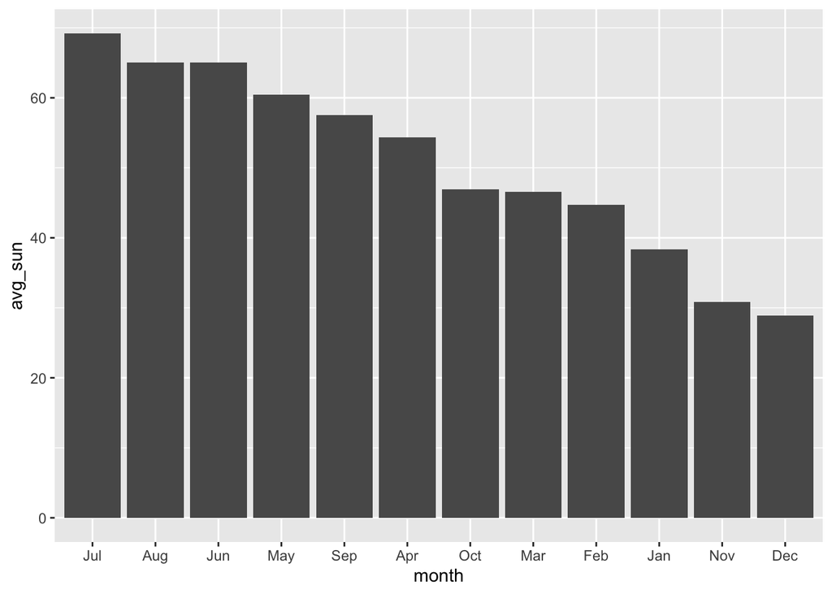

```r
w %>%
  group_by(month) %>%
  summarize(avg_sun = mean(PSUN,na.rm=T), count= n()) %>%
  arrange(desc(avg_sun)) %>%
  mutate(month = factor(month, levels=month)) %>%
  ggplot(mapping=aes(x=month, y=avg_sun)) +
    geom_bar(stat="identity")
```

### Question 11

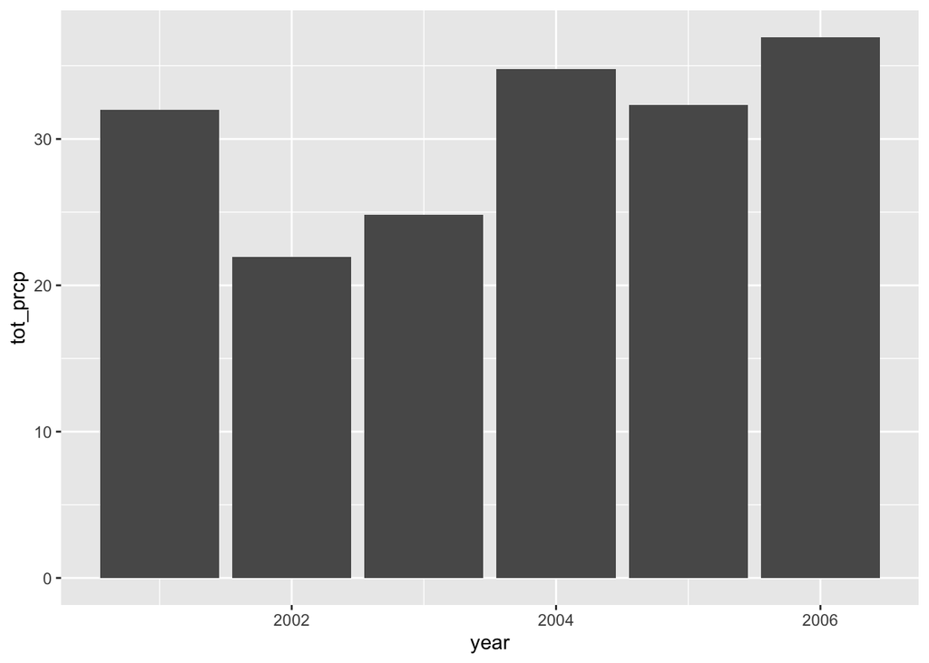

```r
w %>%
  filter(year %in% c(2001,2002,2003,2004,2005,2006)) %>%
  group_by(year) %>%
  summarize(tot_prcp = sum(PRCP)) %>%
  ggplot(mapping=aes(x=year, y=tot_prcp))+
    geom_bar(stat="identity")
```